```
number of holidays
25.0

   ***   DATA IS READY FOR USE   ***
```

# 5 Summary of Linear Regression - Part 1

**Overview:**

- Goal: 1-step ahead consumption prediction in 30 min intervals
- Scope: everything was done for a **single fixed** household, call it household X
- Regressors: temperature, time of the day, day of the year, auto-regressors with different lags
- Methodology: linear regression

**What has been done so far:**

- Data cleaning
- Feature selection with RFECV and PACF+CV methods
- Significance analysis
- Visulaization

**Results:**

- The general trend can be modeled
- Sudden high peaks are underestimated
- Both feature selection methods obtain similar error measures
- The number of selected features is less than 20
- Important features are among 48k +/- 2, k between 0 and 7

**To do next:** Improving the fit for household X

- Are outliers the only source of error?
- 1 hour resolution
- Modeling the residuals

Robustenss analysis:

- Effect of weekday
- Effect of time of the day
- Comparing error between different households

Federation:

- Is this problem a good instance for federated learning?

# 6 Improving the Fit

**6.0 Setup**

- Data from the main household (X)
- Try to improve the fit results for the main household (X)
- Naive results of the previous notebook: MSE=0.2, Adj. R2 = 0.49

**6.1 Remove Outliers of Consumption**

- 30 min resolution
- Only Thursdays
- Results: low MSE, but too many points were removed
- Not an interesting setup

**6.2 Predict Hourly Consumption**

- Household X, only Thursdays
- Switch from 30 min resolution to 1 hour
- Results: improved

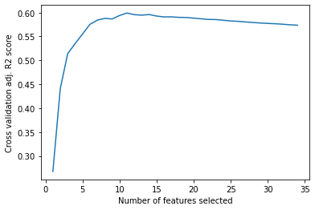

```
Recurssive Feature Elimination + CV
Optimal number of features: 11
Selected features:
['constant', 'hourofd_x', 'hourofd_y', 'lag 1', 'lag 24', 'lag 48', 'lag 72', 'lag 96', 'lag 120', 'lag 144', 'lag 168']
Train R2 scores: 0.6187772479606405, 0.6226141660572238, 0.6345449231033988, 0.6179337088285279, 0.6223863860297522
Test  R2 scores: 0.6387577026693276, 0.623459097760389, 0.5738530472058496, 0.6399018002914589, 0.623457053536522
Mean absolute error: train 0.24, test 0.23
Mean squared error:  train 0.11, test 0.11
Explained Variance Score (best=1): train 0.62, test 0.64
Coefficient of determination (R2): train 0.62, test 0.64
Adjusted coeff. of determination:  train 0.62, test 0.64
AIC: train 9.21, test 12.08
```

**6.3 Modeling the Residuals** Not done

# 7 Changing The Assumptions

In this section, we change some of the general assumptions to evaluate regression robustness or try to improve the fit

**7.1 Effect of the part of the day**

```
---------morning---------
```

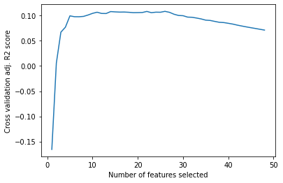

```
Recurssive Feature Elimination + CV
Optimal number of features: 26
Selected features:
['constant', 'hourofd_x', 'hourofd_y', 'dayofy_y', 'temperature_hourly', 'lag 2', 'lag 3', 'lag 47', 'lag 48', 'lag 94', 'lag 95', 'lag 96', 'lag 99', 'lag 144', 'lag 145', 'lag 147', 'lag 192', 'lag 193', 'lag 195', 'lag 238', 'lag 240', 'lag 241', 'lag 288', 'lag 334', 'lag 335', 'lag 336']
Train R2 scores: 0.20536928213968464, 0.19879075097541454, 0.20447530928268864, 0.19897061725685872, 0.21349920683995482
Test  R2 scores: 0.17629436956940614, 0.2043323803192978, 0.1849274241297455, 0.2062266591130567, 0.1515071371710499
Mean absolute error: train 0.46, test 0.47
Mean squared error:  train 0.35, test 0.37
Explained Variance Score (best=1): train 0.20, test 0.21
Coefficient of determination (R2): train 0.20, test 0.21
Adjusted coeff. of determination:  train 0.19, test 0.20
AIC: train 36.45, test 39.07

---------noon---------
```

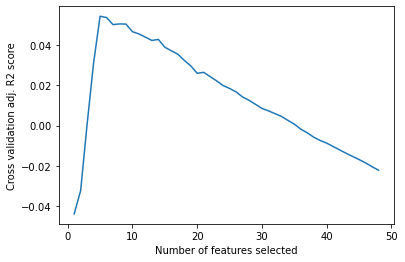

```
Recurssive Feature Elimination + CV
Optimal number of features: 5
Selected features:
['hourofd_x', 'hourofd_y', 'dayofy_y', 'lag 1', 'lag 336']
Train R2 scores: 0.10191875124619842, 0.09786873741939506, 0.09742251902578924, 0.107863174847453, 0.08838463292135124
Test  R2 scores: 0.07888682848996187, 0.09455065979434207, 0.09469930913716273, 0.055515024553797754, 0.12921546975773424
Mean absolute error: train 0.37, test 0.38
Mean squared error:  train 0.23, test 0.26
Explained Variance Score (best=1): train 0.09, test 0.13
Coefficient of determination (R2): train 0.09, test 0.13
Adjusted coeff. of determination:  train 0.09, test 0.13
AIC: train -2.74, test -0.17

---------afternoon---------
```

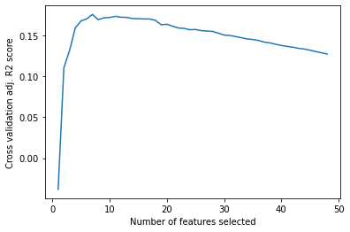

```
Recurssive Feature Elimination + CV
Optimal number of features: 7
Selected features:
['constant', 'hourofd_y', 'temperature_hourly', 'lag 48', 'lag 96', 'lag 144', 'lag 288']
Train R2 scores: 0.23988660255601613, 0.2367425163899317, 0.23400828002604368, 0.2331821353686645, 0.24515278010516073
Test  R2 scores: 0.22696454776687114, 0.23195686919239744, 0.24683609248987892, 0.2548954355279819, 0.19888110742010146
Mean absolute error: train 0.29, test 0.27
Mean squared error:  train 0.14, test 0.12
Explained Variance Score (best=1): train 0.23, test 0.26
Coefficient of determination (R2): train 0.23, test 0.25
Adjusted coeff. of determination:  train 0.23, test 0.25
AIC: train 0.30, test 3.31

---------evening---------
```

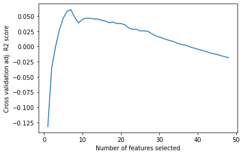

```
Recurssive Feature Elimination + CV
Optimal number of features: 7
Selected features:
['constant', 'temperature_hourly', 'lag 48', 'lag 96', 'lag 143', 'lag 240', 'lag 288']
Train R2 scores: 0.1761708966601444, 0.16110136989703872, 0.1709438187875949, 0.1591112952499356, 0.16285301854317424
Test  R2 scores: 0.11852161504088499, 0.18499979867747707, 0.14503058542503056, 0.18744192653347647, 0.17139585405426727
Mean absolute error: train 0.39, test 0.39
Mean squared error:  train 0.29, test 0.29
Explained Variance Score (best=1): train 0.16, test 0.19
Coefficient of determination (R2): train 0.16, test 0.19
Adjusted coeff. of determination:  train 0.16, test 0.19
AIC: train -1.22, test 1.60

---------night---------
```

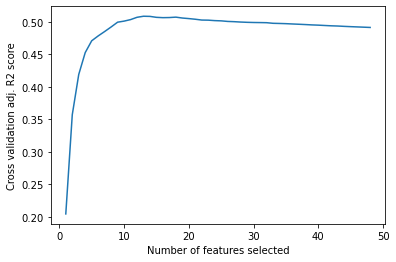

```
Recurssive Feature Elimination + CV
Optimal number of features: 13
Selected features:
['constant', 'lag 1', 'lag 3', 'lag 47', 'lag 48', 'lag 95', 'lag 96', 'lag 143', 'lag 144', 'lag 192', 'lag 240', 'lag 288', 'lag 336']
Train R2 scores: 0.5410139624178565, 0.5450808699506586, 0.5435031598318314, 0.5622160957702631, 0.5536345174739903
Test  R2 scores: 0.5721795230316125, 0.5596927380410907, 0.5685519115545778, 0.49442043234160427, 0.5240287141186182
Mean absolute error: train 0.17, test 0.16
Mean squared error:  train 0.07, test 0.07
Explained Variance Score (best=1): train 0.54, test 0.57
Coefficient of determination (R2): train 0.54, test 0.57
Adjusted coeff. of determination:  train 0.54, test 0.57
AIC: train 12.24, test 14.97
```

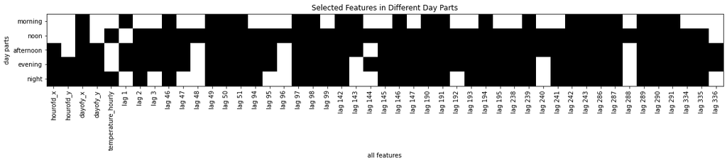

**7.2 Changing the selected weekday**

```
Train R2 scores: 0.4910375796060352, 0.4829046344637069, 0.4865608174017625, 0.48399055639631916, 0.4869485105762701
Test  R2 scores: 0.43536441759428945, 0.4777789652998571, 0.46056707892181703, 0.47178950893987825, 0.4547086128321475
```

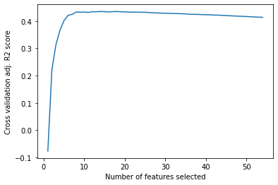

```
Recurssive Feature Elimination + CV
Optimal number of features: 14
Selected features:
['constant', 'lag 47', 'lag 48', 'lag 94', 'lag 144', 'lag 145', 'lag 192', 'lag 193', 'lag 239', 'lag 240', 'lag 241', 'lag 242', 'lag 287', 'lag 288']
Train R2 scores: 0.47301825983357093, 0.47156800483881967, 0.4677807612145878, 0.4755594181447661, 0.4743691277218951
Test  R2 scores: 0.4617132750695393, 0.4687109184286259, 0.4856355009243841, 0.4519806940245704, 0.458535786560441
Train R2 scores: 0.5455563035370337, 0.5582338835346482, 0.5405080865088732, 0.5478468363098026, 0.5533101375217123
Test  R2 scores: 0.5580860513252704, 0.5013217600001185, 0.5698643752692352, 0.547100720138998, 0.5242675488764034
Mean absolute error: train 0.17, test 0.17
Mean squared error:  train 0.07, test 0.08
Explained Variance Score (best=1): train 0.54, test 0.57
Coefficient of determination (R2): train 0.54, test 0.57
Adjusted coeff. of determination:  train 0.54, test 0.57
AIC: train 12.30, test 14.76
Train R2 scores: 0.483729822721792, 0.48193781185149764, 0.4878604940106678, 0.48684264360051155, 0.4814911335421127
Test  R2 scores: 0.4641696858130061, 0.4722610911653221, 0.4461908804236542, 0.4510801139863386, 0.4721968256888719
```

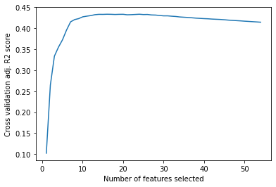

```
Recurssive Feature Elimination + CV
Optimal number of features: 24
Selected features:
['constant', 'lag 1', 'lag 3', 'lag 46', 'lag 47', 'lag 48', 'lag 49', 'lag 50', 'lag 94', 'lag 95', 'lag 96', 'lag 142', 'lag 147', 'lag 192', 'lag 239', 'lag 240', 'lag 241', 'lag 288', 'lag 289', 'lag 334', 'lag 335', 'lag 336', 'lag 337', 'lag 384']
Train R2 scores: 0.468698955010184, 0.48376941503740745, 0.47930418773520755, 0.48048353352309936, 0.4819837020839495
Test  R2 scores: 0.5061837610133655, 0.4497108738467879, 0.46787466069673855, 0.4614843312530458, 0.45756966227926554
Train R2 scores: 0.5531884394366917, 0.5493907346482718, 0.5525613591803555, 0.5424027964919047, 0.5470664640298517
Test  R2 scores: 0.5267052144302964, 0.5410712182599718, 0.5297304995644387, 0.5702588133271564, 0.5514338673897101
Mean absolute error: train 0.17, test 0.17
Mean squared error:  train 0.07, test 0.07
Explained Variance Score (best=1): train 0.54, test 0.57
Coefficient of determination (R2): train 0.54, test 0.57
Adjusted coeff. of determination:  train 0.54, test 0.57
AIC: train 12.21, test 15.10
Train R2 scores: 0.4797486625708455, 0.47894621931583936, 0.4870202702816492, 0.47866432003800263, 0.4812783691927164
Test  R2 scores: 0.46773213309408956, 0.47044224965449954, 0.4400928037351577, 0.47098756379266915, 0.4620666556356201
```

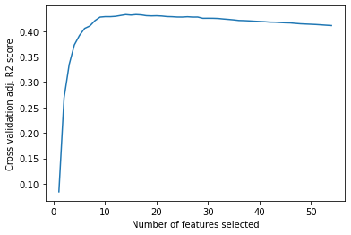

```
Recurssive Feature Elimination + CV
Optimal number of features: 16
Selected features:
['constant', 'hourofd_x', 'lag 1', 'lag 3', 'lag 47', 'lag 48', 'lag 94', 'lag 95', 'lag 96', 'lag 98', 'lag 240', 'lag 288', 'lag 336', 'lag 337', 'lag 383', 'lag 384']
Train R2 scores: 0.4734218451269231, 0.46936407608235764, 0.4648407373615704, 0.47470648598065457, 0.46929414232801536
Test  R2 scores: 0.45009270900921006, 0.4663839854228816, 0.47963902025132876, 0.4470588714226522, 0.4657356694001874
Train R2 scores: 0.5505287489345124, 0.5514129421624099, 0.5554873244746529, 0.5478260236339002, 0.5393659559506802
Test  R2 scores: 0.536047446147556, 0.5359958821429196, 0.513007287628807, 0.5480184740141965, 0.5838973762458414
Mean absolute error: train 0.17, test 0.16
Mean squared error:  train 0.07, test 0.06
Explained Variance Score (best=1): train 0.54, test 0.58
Coefficient of determination (R2): train 0.54, test 0.58
Adjusted coeff. of determination:  train 0.54, test 0.58
AIC: train 12.19, test 15.19
Train R2 scores: 0.5043924745388431, 0.5033666513927852, 0.4997605039474615, 0.49878235049932196, 0.49830101692487494
Test  R2 scores: 0.46365700987744907, 0.47137355423126837, 0.4846389707255756, 0.482657569996947, 0.4906790034480436
```

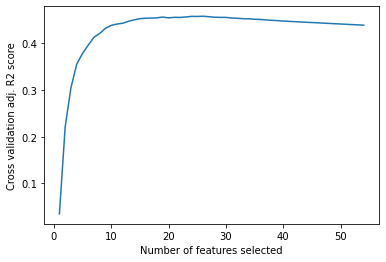

```
Recurssive Feature Elimination + CV
Optimal number of features: 26
Selected features:
['constant', 'hourofd_x', 'hourofd_y', 'dayofy_x', 'dayofy_y', 'temperature_hourly', 'lag 1', 'lag 2', 'lag 3', 'lag 46', 'lag 47', 'lag 48', 'lag 96', 'lag 143', 'lag 144', 'lag 145', 'lag 191', 'lag 192', 'lag 240', 'lag 288', 'lag 291', 'lag 335', 'lag 336', 'lag 337', 'lag 338', 'lag 384']
Train R2 scores: 0.5003663083549017, 0.49889704962862547, 0.49347354761256457, 0.49943403425876365, 0.4982002872891954
Test  R2 scores: 0.4728826569744955, 0.4847663387501744, 0.5034833850931322, 0.47791076439723923, 0.48780093394621316
Train R2 scores: 0.5546232831160673, 0.5455506023917915, 0.5543726661576502, 0.5461955356229646, 0.544553272603645
Test  R2 scores: 0.5251451536384083, 0.558818160752035, 0.5154427534596426, 0.5538257555818056, 0.5626625847817813
Mean absolute error: train 0.17, test 0.17
Mean squared error:  train 0.07, test 0.07
Explained Variance Score (best=1): train 0.54, test 0.56
Coefficient of determination (R2): train 0.54, test 0.56
Adjusted coeff. of determination:  train 0.54, test 0.56
AIC: train 12.19, test 15.19
Train R2 scores: 0.4722606865558504, 0.46918274578776664, 0.4814620639897187, 0.4694639767456934, 0.4676909295309136
Test  R2 scores: 0.4430586758141839, 0.45689398226756306, 0.4178297600235903, 0.45510623745953926, 0.46674194069657016
```

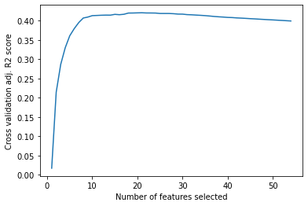

```
Recurssive Feature Elimination + CV
Optimal number of features: 21
Selected features:
['constant', 'dayofy_y', 'lag 1', 'lag 2', 'lag 48', 'lag 50', 'lag 51', 'lag 96', 'lag 97', 'lag 143', 'lag 144', 'lag 191', 'lag 192', 'lag 287', 'lag 288', 'lag 290', 'lag 291', 'lag 335', 'lag 336', 'lag 383', 'lag 384']
Train R2 scores: 0.4631759439122538, 0.45327669997764086, 0.4887857435007167, 0.4637783878011519, 0.4708537198918793
Test  R2 scores: 0.4735239524165813, 0.517971255143667, 0.3876178899371794, 0.47536421597874723, 0.44447314328271625
Train R2 scores: 0.546306827489681, 0.5472591370657991, 0.5569357211657862, 0.5519646287690667, 0.5421494925285946
Test  R2 scores: 0.5552293392638054, 0.5510871553129864, 0.5044510234022648, 0.533036240818664, 0.568547511486732
Mean absolute error: train 0.17, test 0.17
Mean squared error:  train 0.07, test 0.07
Explained Variance Score (best=1): train 0.54, test 0.57
Coefficient of determination (R2): train 0.54, test 0.57
Adjusted coeff. of determination:  train 0.54, test 0.57
AIC: train 12.26, test 14.91
Train R2 scores: 0.4233672904820728, 0.4159569918971696, 0.413929913623054, 0.42124594963542916, 0.4214763974233985
Test  R2 scores: 0.37310760160230794, 0.41144710936665885, 0.41839465597981096, 0.39269445133358494, 0.38450008131849844
```

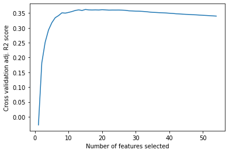

```
Recurssive Feature Elimination + CV
Optimal number of features: 15
Selected features:
['constant', 'hourofd_x', 'dayofy_y', 'lag 1', 'lag 47', 'lag 48', 'lag 49', 'lag 95', 'lag 96', 'lag 98', 'lag 142', 'lag 145', 'lag 241', 'lag 336', 'lag 337']
Train R2 scores: 0.41400192222064225, 0.4091532510947833, 0.40145127533959246, 0.40704791508564275, 0.41018949802147375
Test  R2 scores: 0.3794510173038679, 0.39704163411068094, 0.4242586538095555, 0.40713731126291874, 0.391213440349121
Train R2 scores: 0.538851582831914, 0.5586301275124294, 0.5468763756783943, 0.5409892696635862, 0.5591964658763589
Test  R2 scores: 0.5823454572286726, 0.5062282577381376, 0.5522193927667713, 0.5781536139458727, 0.5009340422730202
Mean absolute error: train 0.17, test 0.17
Mean squared error:  train 0.07, test 0.07
Explained Variance Score (best=1): train 0.54, test 0.58
Coefficient of determination (R2): train 0.54, test 0.58
Adjusted coeff. of determination:  train 0.54, test 0.58
AIC: train 12.22, test 15.07
Train R2 scores: 0.46605834795131285, 0.4633367562067541, 0.464420057384927, 0.471833456506516, 0.4647602440095068
Test  R2 scores: 0.4453838327455356, 0.4527305541291482, 0.4497954080534814, 0.42043392194183704, 0.44690072039878004
```

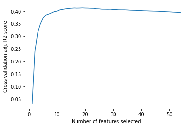

```
Recurssive Feature Elimination + CV
Optimal number of features: 19
Selected features:
['constant', 'hourofd_x', 'hourofd_y', 'temperature_hourly', 'lag 1', 'lag 47', 'lag 48', 'lag 49', 'lag 97', 'lag 99', 'lag 144', 'lag 145', 'lag 147', 'lag 192', 'lag 240', 'lag 334', 'lag 335', 'lag 336', 'lag 337']
Train R2 scores: 0.46764728965973035, 0.45252731352995623, 0.4659776386672947, 0.45746567708326547, 0.46100170201107926
Test  R2 scores: 0.42977309228764304, 0.48841896127302464, 0.4300592828926013, 0.4708138022464975, 0.45579808827648227
Train R2 scores: 0.5574126758670481, 0.5461954205524948, 0.5441137889823446, 0.5476939374748351, 0.5491502309209759
Test  R2 scores: 0.49818977979203116, 0.5565845440968495, 0.5609255807917883, 0.5503794715444765, 0.5421620165420908
Mean absolute error: train 0.17, test 0.17
Mean squared error:  train 0.07, test 0.08
Explained Variance Score (best=1): train 0.54, test 0.56
Coefficient of determination (R2): train 0.54, test 0.56
Adjusted coeff. of determination:  train 0.54, test 0.56
AIC: train 12.28, test 14.83
```

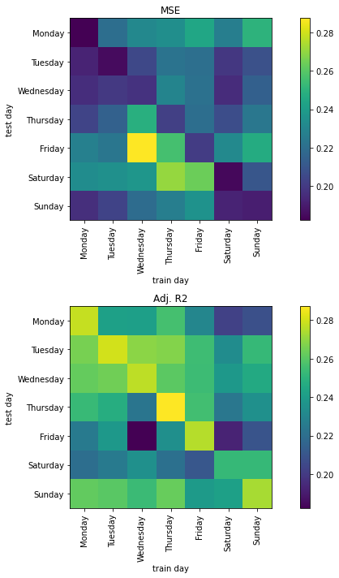

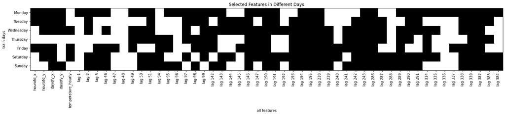

**7.3 Changing the house**

- Test procedure on 100 houses
- RFECV feature selection + linear model
- Compare against Acorn groups, electricity tariff
- Results: huge differences among houses/groups

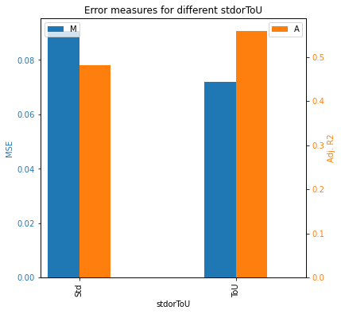

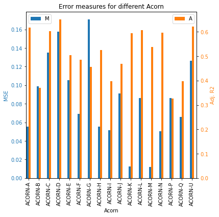

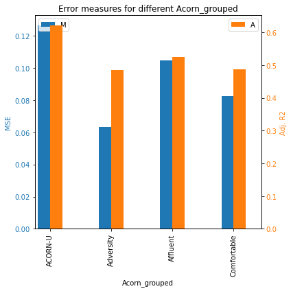

# 8 Federated Learning

In this section we run some initial tests to see if this problem is a good case for FL

**8.1 Can consumption of a number of houses from the same group be predicted by a linear model?**

- 10 houses
- ACORON L (b.c. was the group for the main household)
- 1-step-ahead prediction
- RFECV feature selection
- remove non-significant features
- Results: obtains a very nice fit

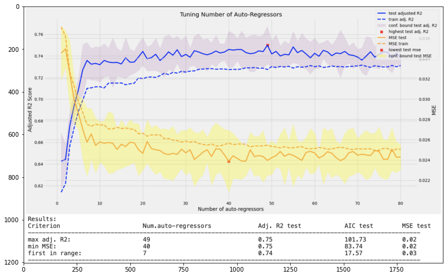

```
Using lags:
[  1   2  45  46  47  48 336]
Train R2 scores: 0.691630253262587, 0.7067848194569657, 0.6930596316635763, 0.6961452100960426, 0.7006022907058891
Test  R2 scores: 0.7205129639275407, 0.6578753458901945, 0.7120381715716231, 0.6999949114828092, 0.6831121299674798
Mean absolute error: train 0.13, test 0.13
Mean squared error:  train 0.03, test 0.03
Explained Variance Score (best=1): train 0.69, test 0.72
Coefficient of determination (R2): train 0.69, test 0.72
Adjusted coeff. of determination:  train 0.69, test 0.72
AIC: train 14.29, test 17.36
```

**8.2 What if households of different groups are mixed?**

```
number of holidays
25.0

   ***   DATA IS READY FOR USE   ***
```

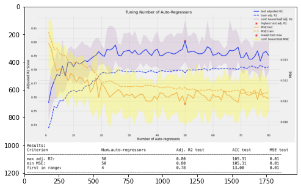

```
Using lags:
[ 1 42 43 45]
Train R2 scores: 0.7563140200546077, 0.7566218119638943, 0.7598692894670269, 0.7605161617571558, 0.7566165744959112
Test  R2 scores: 0.762676379434474, 0.762434099584424, 0.7475086990770231, 0.7467487472749863, 0.7621180010347263
Mean absolute error: train 0.08, test 0.09
Mean squared error:  train 0.01, test 0.01
Explained Variance Score (best=1): train 0.76, test 0.76
Coefficient of determination (R2): train 0.76, test 0.76
Adjusted coeff. of determination:  train 0.76, test 0.76
AIC: train 10.12, test 12.72
```

**8.3 How well can a global model predict consumption of individuals?**

- Test models from 8.1 and 8.2 on the household we've been working with

```
Testing model trained on the same ACORON group (7.1)
Mean absolute error: train 0.40, test 0.38
Mean squared error:  train 0.37, test 0.31
Explained Variance Score (best=1): train 0.33, test 0.36
Coefficient of determination (R2): train 0.09, test 0.14
Adjusted coeff. of determination:  train 0.09, test 0.13
AIC: train 9.45, test 12.58

Testing model trained on different ACORON groups (7.2)
Mean absolute error: train 0.47, test 0.46
Mean squared error:  train 0.50, test 0.46
Explained Variance Score (best=1): train 0.21, test 0.22
Coefficient of determination (R2): train -0.21, test -0.21
Adjusted coeff. of determination:  train -0.22, test -0.21
AIC: train 2.84, test 5.79
```

# Options:

- Pick another household, do day-ahead prediction
- Group prediction

# Experiment with FL:

- What happens for other groups/other households?
- Are there households/groups for which FL works well?
- Calculate mean and std of error for different houses in the FL dataset

why some houses ave a high error? model when outliers happen, model residuals

# Discussions

**1.** Are nonlinear models needed?

- Intuition: yes; linear models cannot capture the peaks at some parts of the day so nonlinear models might be needed. Lin reg + FL is not good, maybe nonlin+FL works well.
- How to test: use GP on residuals or GP with a kernel that has a linear part

**2.** Is this dataset useful for FL?

- Observation: applying the model trained to predict mean consumption of 10 houses for predicting the consumption of household X results in a high MSE
- Conclusion: hoping to learn lin. reg. coefficients with FL is too much
- How to test: fix a set of features, train individual models for different houses using this set of features, check if the distribution of hyperparams is narrow

**3.** Motivation for FL: training a GP needs two years of data. Does having the optimal hyperparameters reduce the number of needed samples?

**4.** Modeling the residuals:

- Either residual of predicting with the individually-trained or FL linear model
- Are the residuals different from white noise? if not, no hope to predict them
- Use days/part of days when residuals are more different from WGN

# Related works:

Compare with: https://www.kaggle.com/nwheeler443/london-smart-meter-analysis-of-half-hourly-data

https://www.kaggle.com/faithmudoti/ruvheneko-energy-consumption-forecast

https://www.kaggle.com/ryuheeeei/smart-home-energy-analysis-with-prophet

https://www.kaggle.com/rheajgurung/energy-consumption-forecast

https://www.kaggle.com/tomneeld/dashboards-and-clustering

https://www.kaggle.com/olliepaul/data-exploration-smart-meters-london

[output not shown]